# Coursework Report

*N* removed NAs: 3

*N* removed typo: 1

*N* removed <18: 31

*N* total clean: 115

| Group | *N* | *M*<sub>age</sub> | *M*<sub>rating</sub> |
| --- | --- | --- | --- |
| Control | 56 | 21.1 | 6.60 |
| Experim | 59 | 20.5 | 5.66 |

**Main analysis results**

*t*(113) = 6.81, *p* < .001

[interactive chart not shown]

[figure not shown]

[interactive chart not shown]

# Coursework Report

Analysing Data, Spring 2020

## Participants

In total, 150 participants (*M*<sub>age</sub> = 20.81, *SD*<sub>age</sub> = 2.06, range = 18 - 26) voluntarily took part in the experiment. Following a review of the data, 31 participants were removed from the study for being too young (< 18) and a further 4 participants were also removed for failing to disclose their age. In total, the data of 115 participants was included in the following analysis. A full description of the final sample, categorised by experimental condition is shown in table 1.

Table 1. *Description of Participants by Experimental Condition*

| Condition | N | *M*<sub>age</sub> | *SD*<sub>age</sub> |
| --- | --- | --- | --- |
| Control | 56 | 21.1 | 2.15 |
| Experimental | 59 | 20.5 | 1.93 |

## Design

The present study was designed to investigate whether colour, specifically the colours red and white influence women’s ratings of male attractiveness, and to reexamine Elliot et.al (2010)’s reported red effect by closely replicating the first experiment from their original study. Participants were randomly assigned into one of the two between-subjects colour conditions and viewed the same black and white image displaying the head and upper body of a moderately attractive Caucasian man that was used by Elliot et.al (2010). The image was centered on a white background in the control condition and a red background in the experimental condition.The dependent variable, perceived attractiveness, was assessed using the same three test items that were used by Elliot et.al (2010) which were rated on a 1-9 point numeric scale, where 1 was “not at all attractive” and 9 was “extremely attractive”. Item 1 asked “How attractive do you think this person is?”, item 2 asked “How pleasant is this person to look at?” and item 3 asked “If I were to meet the person in this picture face to face, I would think he is attractive”. The scores of these three test items were then averaged to form a composite score, respresenting the total rating of perceived attractiveness for each condition.

The following statistical analysis was carried out using an independent measures t-test in R-studio. Our operational hypothesis stated that: The colours red and white will influence women’s ratings of attractiveness for the target image, as measured by the composite score of test items 1, 2 and 3.

# Results

*Table 2*. Description of mean ratings by Condition

| Condition | *M*<sub>item1</sub> | *SD*<sub>item1</sub> | *M*<sub>item2</sub> | *SD*<sub>item2</sub> | *M*<sub>item3</sub> | *SD*<sub>item3</sub> | *M*<sub>attract</sub> | *SD*<sub>attract</sub> |
| --- | --- | --- | --- | --- | --- | --- | --- | --- |
| Control | 6.70 | 1.25 | 6.48 | 1.21 | 6.61 | 1.41 | 6.60 | 0.70 |
| Experimental | 5.81 | 1.29 | 5.58 | 1.54 | 5.59 | 1.25 | 5.66 | 0.76 |

As shown in figure 1, results from the experiment revealed that participants in the control condition rated the target image as being more attractive than those in the experimental condition (*M*<sub>white</sub> = 6.6; *M*<sub>red</sub> = 5.66) and an independent measures t-test conducted in R-studio determined that this difference was significant (*M*<sub>diff</sub> = 0.93), 95% CI [0.66, 1.21], *t*(113) = 6.81, *p* = < 0.001). This therefore suggests that perceived attractiveness is significantly influenced by colour, thus supporting the experimental hypothesis. A full summary of the results, displaying means and standard deviations of ratings for each test item, categorised by experimental condition is shown in table 2.

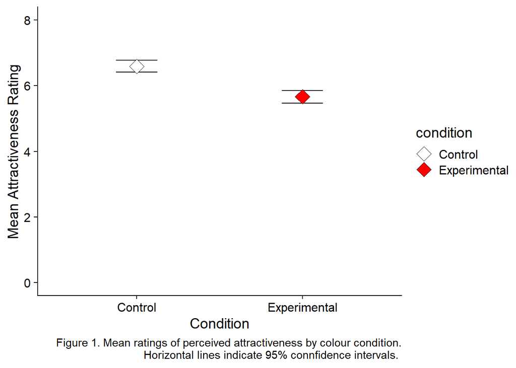

# Discussion

The main aims of the present study were to investigate whether colour influences women’s perceptions of male attractiveness, and to gain further insight into Elliot et al. (2010)’s reported red effect by closely replicating the first experiment from their original paper. Our experiment revealed that women’s ratings of perceived attractiveness in the control (white) condition were higher than in the experimental (red) condition, and that this difference was statistically significant, therefore implicating a clear effect of colour on women’s perceptions of male attractiveness.

Crucially, the findings of the present study contradict those of Elliot et al. (2010), despite being a close replication that utilised a larger sample. Whereas Elliot et al. (2010) reported a statistically significant preference amongst females for the target photo when viewed in conjunction with the colour red across four countries (*M*<sub>white</sub> = 5.67/ *M*<sub>red</sub> = 6.79), the present study found the opposite effect. Of course, despite our experiment being a close replication of Elliot et al (2010)’s first experiment, in that it, (a) investigated the same research question, (b) utilised the same target image, (c) used the same 2-leveled independent variable (colour condition), and (d) operationalised attractiveness using the composite score of the same three test items that were used by Elliot et.al (2010) which were rated on the same 1-9 point Likert scale- it’s appropriate to note that replications of a study will never be perfect (Hunter, 2001). However, this notwithstanding, the findings of the present study do appear to join a growing body of failed replcations and general criticism’s of Elliot.al’s original findings.

Following a statistical analysis of the results published by Elliot et.al (2010), Francis (2013) posited that the experiments lack enough statistical power to support their respective hypotheses and indicated that the probability of all 12 experiments rejecting the null hypothesis was only .005. Moreover, Francis argued that the experiments were “contaminated with publication bias”, suggesting that they were either conducted incorrectly, or that data with null findings was omitted from the paper. In response to Francis, Elliot & Maier (2013) replicated the third experiment from Elliot et.al (2010), which examined the effects of red and grey on women’s ratings of attractiveness. Their replication found that the target photo was rated as more attractive when viewed in conjunction with the colour red (*M*<sub>grey</sub> = 5.80/ *M*<sub>red</sub> = 6.53), but that this difference was not significant (*p* = 0.13).

As well, in another close replication of Elliot et.al (2010’s) first experiment, Hesslinger, Goldbach & Carbon (2015) found only a small, statistically insignificant preference for the target image in the red condition (*M*<sub>white</sub> = 5.39/ *M*<sub>red</sub> = 5.79). Whilst these findings, and the findings of Elliot and Maier (2013) seem to contrast those of the present study by finding a small, albeit insignificant preference for the colour red within their samples, all three replications, including our own, have failed to find a significant red effect. Indeed, the failure to replicate Elliot et.al (2010) and the sharp variation in findings from three conceptually similar experiments highlights the seriousness of the ongoing ‘Replication Crisis’, and emphasises the need for improvement of the methods and practises that are currently used in the wider field of experimental Psychology (Shrout & Rodgers, 2018; see also, Anderson & Maxwell, 2017).

Furthermore, by failing to replicate Elliot et.al (2010), the present experiment also questions the mechanisms by which any existing red effect might occur. Existing ethological research has suggested that red can act as a signal of status, dominance rank, and male sexual quality in a variety of species, including fish (Bakker & Sevenster, 1983) , finches (Cuthill, Hunt, Cleary & Clark, 1997), reptiles (Healey, Uller & Olsson, 2007) and non-human primates (Setchell & Jean Wickings, 2005; Setchell & Dixson, 2001), where the most sexually competitive alpha males display the largest, most prominent red facial colouration. Elliot et.al (2010) assert that their research demonstrates “clear parallels” in the way that human and non-human females perceive male redness and suggest that red as a mechanism of signalling male status might account for the red effect in women viewing men. However, our research appears to suggest that this is not the case, given that red did not increase attractiveness. Moreover, Hesslinger, Goldbach & Carbon (2015) found no significant effect of red on ratings of perceived status and in doing so, challenge the biological mechanism by which Elliot et.al (2010) suggest the red effect might arise from.

In sum, the colour red is associated with an array of religious, political, and social concepts, such as temptation, communist revolution, and sexual passion across different cultures (Hogarth, 2012). Whereas Elliot et.al (2010) reported a statistically significant red effect across four different countries, our experiment challenges these findings as well as the proposed mechanisms by which they might arise from by, perhaps paradoxically, finding the opposite effect. That said, a general limitation of the present study was it was restricted to replicating the same method that was used in Elliot et.al (2010)’s first experiment and therefore failed to test the same diverse set of experiments that Elliot et.al were able to draw their conclusions from. Furthermore, the results of the present study sharply contrast with the findings of Elliot et.al’s (2010) and other replications. Therefore, our results should be interpreted cautiously, and should not serve as the basis for any certain conclusions to the existence or power of the red effect in the absence of further replications.

# References

Anderson, S., & Maxwell, S. (2017). Addressing the “Replication Crisis”: Using Original Studies to Design Replication Studies with Appropriate Statistical Power. Multivariate Behavioral Research, 52(3), 305-324. doi: 10.1080/00273171.2017.1289361.

Bakker, T., & Sevenster, P. (1983). Determinants of Dominance in Male Sticklebacks (Gasterosteus Aculeatus L.). Behaviour, 86(1-2), 55-71. doi: 10.1163/156853983x00561.

Cuthill, I., Hunt, S., Cleary, C., & Clark, C. (1997). Colour bands, dominance, and body mass regulation in male zebra finches (Taeniopygia guttata). Proceedings Of The Royal Society Of London. Series B: Biological Sciences, 264(1384), 1093-1099. doi: 10.1098/rspb.1997.0151.

Elliot, A. J., Niesta Kayser, D., Greitemeyer, T., Lichtenfeld, S., Gramzow, R. H., Maier, M. A., & Liu, H. (2010). Red, rank, and romance in women viewing men. *Journal of Experimental Psychology: General, 139*(3), 399.

Elliot, A., & Maier, M. (2013). The red-attractiveness effect, applying the Ioannidis and Trikalinos (2007b) test, and the broader scientific context: A reply to Francis (2013). Journal Of Experimental Psychology: General, 142(1), 297-300. doi: 10.1037/a0029592.

Francis, G. (2012). Publication bias and the failure of replication in experimental psychology. Psychonomic Bulletin & Review, 19(6), 975-991. doi: 10.3758/s13423-012-0322-y

Francis, G. (2013). Publication bias in “Red, rank, and romance in women viewing men,” by Elliot et al. (2010). Journal Of Experimental Psychology: General, 142(1), 292-296. doi: 10.1037/a0027923.

Healey, M., Uller, T., & Olsson, M. (2007). Seeing red: morph-specific contest success and survival rates in a colour-polymorphic agamid lizard. Animal Behaviour, 74(2), 337-341. doi: 10.1016/j.anbehav.2006.09.017.

Hesslinger, V., Goldbach, L., & Carbon, C. (2015). Men in red: A reexamination of the red-attractiveness effect. Psychonomic Bulletin & Review, 22(4), 1142-1148. doi: 10.3758/s13423-015-0866-8.

Hogarth, H. (2012). Changing Traditions in Colour Symbolism. The 6Th World Congress Of Korean Studies, 25-26, 1-16. Retrieved from https://congress.aks.ac.kr:52525/korean/files/2_1357266009.pdf.

Hunter, J. (2001). The Desperate Need for Replications. Journal Of Consumer Research, 28(1), 149-158. doi: 10.1086/321953.

Setchell, J., & Dixson, A. (2001). Arrested development of secondary sexual adornments in subordinate adult male mandrills (Mandrillus sphinx). American Journal Of Physical Anthropology, 115(3), 245-252. doi: 10.1002/ajpa.1079

Setchell, J., & Jean Wickings, E. (2005). Dominance, Status Signals and Coloration in Male Mandrills (Mandrillus sphinx). Ethology, 111(1), 25-50. doi: 10.1111/j.1439-0310.2004.01054.x

Shrout, P., & Rodgers, J. (2018). Psychology, Science, and Knowledge Construction: Broadening Perspectives from the Replication Crisis. Annual Review Of Psychology, 69(1), 487-510. doi: 10.1146/annurev-psych-122216-011845